# Progetto slides

## ANALISI VENDITE NEL MERCATO AUTOMOBILISTICO DEGLI EMIRATI ARABI UNITI

**Matteo Raffin**

### Dominio e motivazioni dello studio

Il dominio del progetto riguarda la vendita di autombobili del mercato di riferimento degli Emirati Arabi Uniti (UAE). Si vogliono indagare le preferenze e le caratteristiche del mercato.

Le motivazioni relative alla scelta del dominio sono:

- passione del mondo automobilistico
- curiosità sulle caratteristiche del mercato aumobilistico UAE

### I dataset

Per lo studio si sono usati 2 dataset:

- UAE auto market sales data for advanced analytics (https://www.kaggle.com/datasets/azharsaleem/uae-auto-market-sales-data-for-advanced-analytics): i dati sono riferiti al mese di Aprile 2024.
- UAE_Official_Boundaries (https://github.com/justinelliotmeyers/UAE_Official_Boundaries): esso contiene il dataset dei confini degli Emirati Arabi Uniti. I dati sono disponibili dal 2020.

### Trasformazioni ai dataset

I dataset hanno subito delle trasformazioni prima dell'analisi:

- eliminazioni di colonne
- conversioni di valori
- cambiamento di nomi di colonne
- cambiamento ordine di colonne
- aggiunta di colonne

### Domande dello studio

- Quali sono le nazionalità dei marchi e i tipi di carrozzeria più venduti?
- Esistono correlazioni significative tra i dati?
- Qual è la distribuzione delle vendite sul territorio?
- A parità di tipo di carrozzeria, come sono le distribuzioni del prezzo rispetto la nazionalità del brand?

### Domanda 1:

Quali sono i tipi di carrozzeria più venduti?

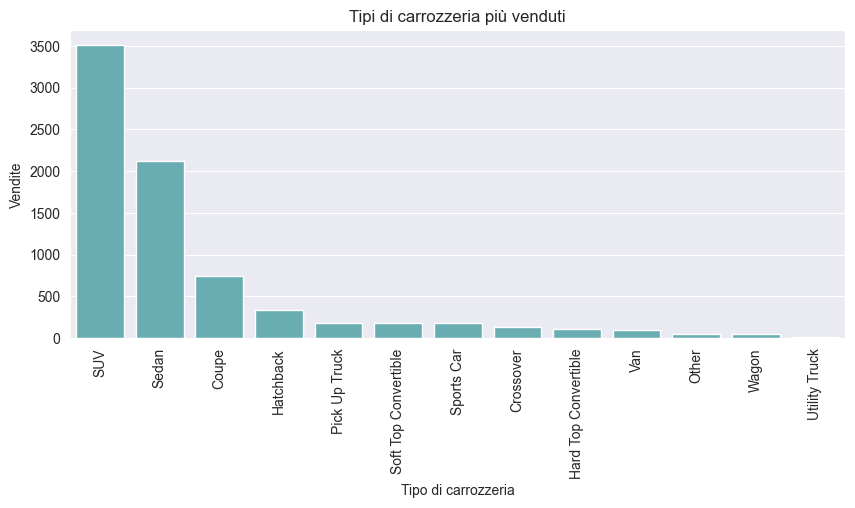

I tipi di carrozzeria più venduti sono i SUV (45.6%), seguiti dalle Sedan (27.5%), seguite dalle Coupé (9.6%).

Quali sono le nazionalità dei marchi automobilistici più venditi?

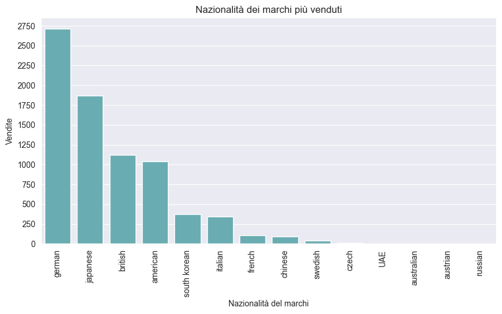

I marchi più venduti sono quelli tedeschi (35.2%), seguiti dai giapponesi (24.2%), seguiti dai britannici (14.6%).

Quali sono le nazionalità dei marchi automobilistici più venduti rispetto al tipo di carrozzeria? (si considerano solo i primi 10 risultati)

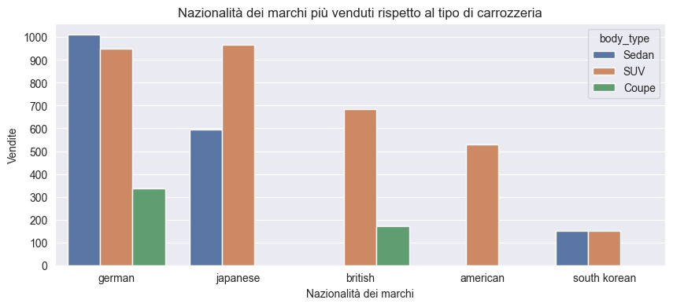

I marchi tedeschi sono i più venduti. Considerando il tipo di carrozzeria primeggiano le Sedan (13.1%) e le Coupé (4.4%). I marchi giapponesi guidano le vendite dei SUV (12.5%).

### Domanda 2

Esistono correlazioni significative tra i dati?

Calcoliamo i coefficienti di Pearson, Spearman e Kendall sui dati. Emerge una moderata correlazione positiva tra il numero di chilometri e gli anni di età dei mezzi.

```
Pearson: 0.508 (p=0.00e+00)

Spearman: 0.808 (p=0.00e+00)

Kendall: 0.643 (p=0.00e+00)
```

Il coefficiente di Spearman è quello che più tende a 1.

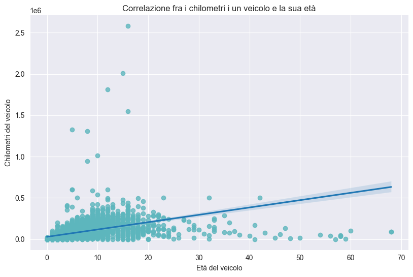

Si osserva una moderata correlazione positiva, con una concentrazione dei punti molto densa.

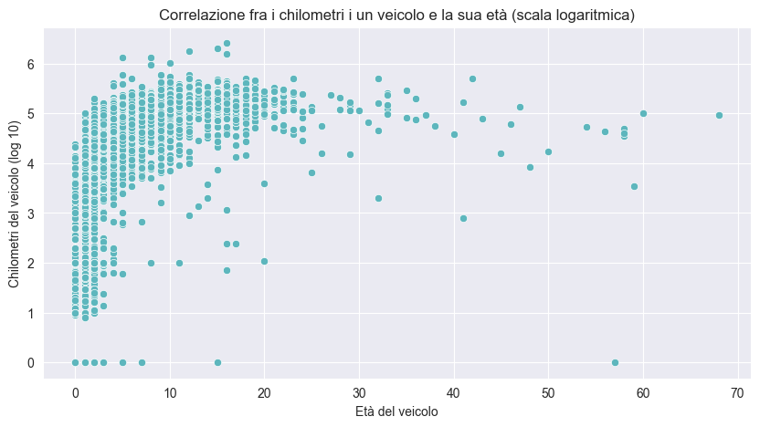

Si osserva che i punti sono più distribuiti e seguono l'andamento della funzione logaritmo.

### Domanda 3

Qual è la distribuzione delle vendite sul territorio?

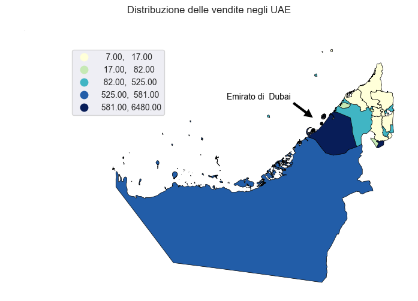

|  | name | sales |
| --- | --- | --- |
| 0 | Dubai | 6480 |
| 1 | Abu Dhabi | 581 |
| 2 | Sharjah | 525 |
| 3 | Ajman | 82 |
| 4 | Umm Al Quwain | 17 |
| 5 | Ras Al Khaimah | 13 |
| 6 | Fujairah | 7 |

Il mercato ha una densità maggiore nell'Emirato di Dubai

### Domanda 4

A parità di tipo di carrozzeria, come sono le distribuzioni del prezzo rispetto la nazionalità del brand? Si analizza il fenomeno rispetto alle vendite dei SUV dei brand tedeschi, giapponesi e britannici.

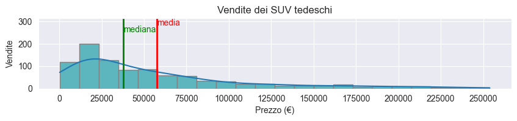

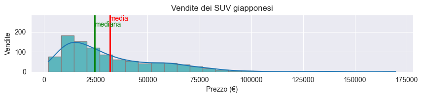

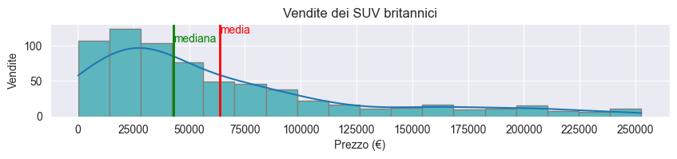

### Conclusioni

- I tipi di carrozzeria più venduti sono i SUV, le Sedan e le Coupè
- I marchi più venduti sono quelli tedeschi, giapponesi e britannici
- Le vendite maggiori sono registrate nell'Emirato di Dubai
- In media i SUV giapponesi sono meno costosi rispetto ai SUV tedeschi e britannici
- Sotto i 25.000€, i SUV più venduti sono quelli giapponesi